# main analysis

ailani

9/7/26

# The Multisensory Nature of Iconic Words: A Network Analysis

Load packages

```r
knitr::opts_chunk$set(
  echo = TRUE,
  warning = FALSE,   # hide warnings
  message = FALSE,   # hide messages
  error = FALSE      # hide errors
)
#list of packages (Diveica et al., 2025)
packages <- c("tidyverse", "bootnet", "NetworkComparisonTest", "qgraph", "igraph", "papaja", "ggcorrplot", "rstatix", "psych", "ggrepel", "ggExtra")

#load each package
for (pkg in packages) {
  library(pkg, character.only = TRUE, quietly=TRUE)
}

# notin operator (Diveica et al, 2025)
'%notin%' <- negate('%in%')
```

Load datasets

```r
setwd('/Users/ailani/Projects/iconic-network-analysis/data/')

AOA <- read_csv('kuperman_2012_AOA.csv')
freq <- read_csv('brysbaert_2012_SUBTLEX_POS.csv')
lanc <- read_csv('Lancaster_sensorimotor_norms_for_39707_words.csv')
spec <- read_csv('muraki_2026_specificity.csv')
emot <- read_csv('warriner_2013_affective_norms.csv')
icon <- read_csv("winter_2024_iconicity_ratings_cleaned.csv")
```

Select relevant columns from each dataset

```r
AOA <- AOA %>% select(Word, Rating.Mean) %>%
  rename(AOA = Rating.Mean)

freq <- freq %>%
  rename(Frequency = FREQcount) %>%
  select(Word, Frequency)

lanc <- lanc %>% select(Word, Auditory.mean:Torso.mean) %>%
  mutate(Word = tolower(Word)) %>%
  rename_with(~ str_remove(.x, "\\.mean"), Auditory.mean:Torso.mean)

spec <- spec %>% select(Word, Value) %>%
  rename(Specificity = Value) #make sure if Value is the right column to use

emot <- emot %>% select(Word, A.Mean.Sum, V.Mean.Sum) %>%
  mutate(Valence = abs(V.Mean.Sum - 5)) %>% # Get the valence extremity value
  rename(Arousal = A.Mean.Sum) %>%
  select(Word, Arousal, Valence)


icon <- icon %>% select(word, rating, rating_sd)  %>% #make sure if rating is right column
  rename(Word = word, Iconicity = rating, Iconicity_SD = rating_sd)
```

Join to full dataset

```r
df <- reduce(list(AOA, lanc, spec, emot, icon, freq), inner_join, by = "Word")
```

See how many words overlapped

```r
nrow(df)
```

```
## [1] 6679
```

There are 6679 overlapping words across all the data sets representing the properties of interest.

Log-transform frequency data

```r
# First make sure NAs in Frequency are 0
df <- mutate(df,
  Frequency = ifelse(is.na(Frequency), 0, Frequency))

df <- mutate(df,
      LogFreq = log10(Frequency + 1))
```

Split into two data frames: one with high iconicity words and another with low iconicity (more arbitrary) words. For lack of conventions in iconicity literature, use tertile split.

```r
# Find the tertile cutoffs on iconicity ratings
tertiles <- quantile(df$Iconicity, probs= c(1/3, 2/3), na.rm=TRUE)
cut_low <- tertiles[1]
cut_high <- tertiles[2]

# Split into high-iconicity and low-iconicity word groups
high_iconic <- df %>% filter(Iconicity >= cut_high)
low_iconic <- df %>% filter(Iconicity <= cut_low)
```

Check group size

```r
nrow(high_iconic)
```

```
## [1] 2344
```

```r
nrow(low_iconic)
```

```
## [1] 2227
```

```r
n_match <- min(nrow(high_iconic), nrow(low_iconic))

high_iconic <- high_iconic %>%
  arrange(desc(Iconicity)) %>%
  slice_head(n=n_match) %>%
  mutate(Iconic = "Iconic")

low_iconic <- low_iconic %>%
  arrange(Iconicity) %>%
  slice_head(n=n_match) %>%
  mutate(Iconic = "Non-iconic")
```

Check if the rows of the split data sets are equal, along with their respective means and ranges

```r
# Check
nrow(high_iconic) == nrow(low_iconic)
```

```
## [1] TRUE
```

```r
mean(high_iconic$Iconicity); range(high_iconic$Iconicity); sd(high_iconic$Iconicity)
```

```
## [1] 4.753973
```

```
## [1] 4.100000 6.909091
```

```
## [1] 0.5153958
```

```r
mean(low_iconic$Iconicity);  range(low_iconic$Iconicity);
```

```
## [1] 2.888794
```

```
## [1] 1.300000 3.388889
```

```r
sd(low_iconic$Iconicity)
```

```
## [1] 0.3649643
```

Also get the mean of the SDs (inter-rater variability) for each group

```r
high_iconic %>% summarise(mean_sd = mean(Iconicity_SD, na.rm=TRUE))
```

```
## # A tibble: 1 × 1
##   mean_sd
##     <dbl>
## 1    1.78
```

```r
low_iconic %>% summarise(mean_sd = mean(Iconicity_SD, na.rm=TRUE))
```

```
## # A tibble: 1 × 1
##   mean_sd
##     <dbl>
## 1    1.74
```

```r
df %>% summarise(mean_SD_full = mean(Iconicity_SD, na.rm=TRUE))
```

```
## # A tibble: 1 × 1
##   mean_SD_full
##          <dbl>
## 1         1.81
```

Now, both high iconic group and low iconic group have same number of words: 2227.

The mean iconicity of the high_iconic set is 4.75, SD = 0.52, and the range is 4.10-6.91.

Mean inter-rater SD was 1.78 (High) and 1.74 (Low). These are both slightly lower than full-sample mean SD of 1.81.

```r
t.test(df$Iconicity_SD, mu = 1.775)  # 1.775 = combined High/Low mean, adjust as needed
```

```
##
##  One Sample t-test
##
## data:  df$Iconicity_SD
## t = 8.3673, df = 6678, p-value < 2.2e-16
## alternative hypothesis: true mean is not equal to 1.775
## 95 percent confidence interval:
##  1.802943 1.820042
## sample estimates:
## mean of x
##  1.811493
```

```r
middle_icon_words <- df %>%
  filter(Iconicity > cut_low, Iconicity < cut_high)

mean(middle_icon_words$Iconicity_SD, na.rm = TRUE)
```

```
## [1] 1.918107
```

Combine the split data sets into one (removing the middle iconicity words)

```r
data_both <- bind_rows(high_iconic, low_iconic) %>%
  select(Word, Iconic, everything()) %>%
  mutate(Iconic = factor(Iconic, levels = c("Iconic", "Non-iconic")))
```

Univariate group comparison of semantic dimensions between high iconic vs low iconic words (`broom` package)

```r
# t-tests to compare ratings between high-iconic vs low-iconic
# list of variables
vars_test <- c("AOA", "Auditory", "Gustatory","Haptic", "Interoceptive", "Olfactory", "Visual", "Foot_leg", "Hand_arm", "Head", "Mouth", "Torso", "Specificity", "Arousal", "Valence")

results <- map_dfr(vars_test, function(var) {
  formula <- as.formula(paste(var,"~ Iconic"))
  t_result <- t.test(formula, data=data_both)

  tidy(t_result) %>%
    mutate(Variable = var) %>%
    select(Variable, estimate, statistic, p.value, conf.low, conf.high)
})
```

Adjust for multiple comparisons with Bonferroni correction (following Diveica et al., 2025)

```r
results <- results %>%
  mutate(p_adj = p.adjust(p.value, method="bonferroni")) %>%
  arrange(p_adj)

print(results)
```

```
## # A tibble: 15 × 7
##    Variable      estimate statistic  p.value conf.low conf.high    p_adj
##    <chr>            <dbl>     <dbl>    <dbl>    <dbl>     <dbl>    <dbl>
##  1 AOA           -1.03      -13.9   3.42e-43  -1.18    -0.886   5.13e-42
##  2 Arousal        0.354      13.1   1.74e-38   0.301    0.407   2.61e-37
##  3 Haptic         0.304      10.6   9.50e-26   0.247    0.360   1.42e-24
##  4 Hand_arm       0.248       8.97  4.21e-19   0.194    0.302   6.32e-18
##  5 Foot_leg       0.211       8.95  5.02e-19   0.165    0.258   7.53e-18
##  6 Specificity    0.0250      7.84  5.73e-15   0.0188   0.0313  8.59e-14
##  7 Visual         0.190       6.97  3.52e-12   0.137    0.244   5.27e-11
##  8 Valence        0.159       6.91  5.66e-12   0.114    0.204   8.50e-11
##  9 Torso          0.148       6.84  8.76e-12   0.106    0.191   1.31e-10
## 10 Interoceptive  0.151       5.12  3.21e- 7   0.0930   0.208   4.81e- 6
## 11 Head          -0.0895     -4.03  5.65e- 5  -0.133   -0.0460  8.47e- 4
## 12 Mouth         -0.0946     -3.24  1.19e- 3  -0.152   -0.0374  1.78e- 2
## 13 Auditory      -0.0669     -2.12  3.37e- 2  -0.129   -0.00514 5.06e- 1
## 14 Gustatory     -0.0121     -0.533 5.94e- 1  -0.0567   0.0324  1   e+ 0
## 15 Olfactory     -0.00220    -0.109 9.13e- 1  -0.0419   0.0375  1   e+ 0
```

Calculate the effect sizes (Cohen’s d)

```r
effect_sizes <- map_dfr(vars_test, function(var){
  formula <- as.formula(paste(var, "~ Iconic"))
  d <- cohens_d(formula, data=data_both)
  tibble(Variable = var, effsize= d$effsize, magnitude = d$magnitude)
})

results <- results %>%
  left_join(effect_sizes, by = "Variable")

print(results)
```

```
## # A tibble: 15 × 9
##    Variable     estimate statistic  p.value conf.low conf.high    p_adj  effsize
##    <chr>           <dbl>     <dbl>    <dbl>    <dbl>     <dbl>    <dbl>    <dbl>
##  1 AOA          -1.03      -13.9   3.42e-43  -1.18    -0.886   5.13e-42 -0.417
##  2 Arousal       0.354      13.1   1.74e-38   0.301    0.407   2.61e-37  0.393
##  3 Haptic        0.304      10.6   9.50e-26   0.247    0.360   1.42e-24  0.316
##  4 Hand_arm      0.248       8.97  4.21e-19   0.194    0.302   6.32e-18  0.269
##  5 Foot_leg      0.211       8.95  5.02e-19   0.165    0.258   7.53e-18  0.268
##  6 Specificity   0.0250      7.84  5.73e-15   0.0188   0.0313  8.59e-14  0.235
##  7 Visual        0.190       6.97  3.52e-12   0.137    0.244   5.27e-11  0.209
##  8 Valence       0.159       6.91  5.66e-12   0.114    0.204   8.50e-11  0.207
##  9 Torso         0.148       6.84  8.76e-12   0.106    0.191   1.31e-10  0.205
## 10 Interocepti…  0.151       5.12  3.21e- 7   0.0930   0.208   4.81e- 6  0.153
## 11 Head         -0.0895     -4.03  5.65e- 5  -0.133   -0.0460  8.47e- 4 -0.121
## 12 Mouth        -0.0946     -3.24  1.19e- 3  -0.152   -0.0374  1.78e- 2 -0.0972
## 13 Auditory     -0.0669     -2.12  3.37e- 2  -0.129   -0.00514 5.06e- 1 -0.0636
## 14 Gustatory    -0.0121     -0.533 5.94e- 1  -0.0567   0.0324  1   e+ 0 -0.0160
## 15 Olfactory    -0.00220    -0.109 9.13e- 1  -0.0419   0.0375  1   e+ 0 -0.00326
## # ℹ 1 more variable: magnitude <ord>
```

Visualize the differences with violin plots

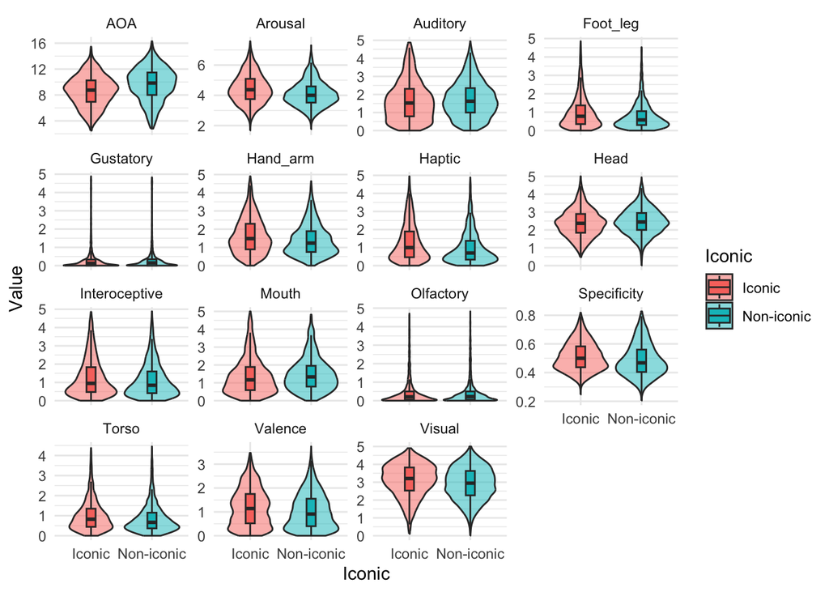

```r
# Reshape data to long format
both_long <- data_both %>%
  select(Iconic, all_of(vars_test)) %>%
  pivot_longer(-Iconic, names_to = "Variable", values_to = "Value")

# Build plot
ggplot(both_long,
    aes(x = Iconic, y = Value, fill= Iconic)) +
    geom_violin(alpha=0.5) +
    geom_boxplot(width=0.15, outlier.shape = NA) +
    facet_wrap(~ Variable, scales= "free_y") +
    theme_minimal()
```

Correlation martix for full data set

```r
library(dplyr)
cor_data <- df %>%
  select(all_of(vars_test), Iconicity)

cor_matrix <- cor(cor_data, use="pairwise.complete.obs", method = "pearson")
print(round(cor_matrix,2))
```

```
##                 AOA Auditory Gustatory Haptic Interoceptive Olfactory Visual
## AOA            1.00     0.02     -0.14  -0.31          0.07     -0.16  -0.30
## Auditory       0.02     1.00     -0.17  -0.29          0.08     -0.12  -0.10
## Gustatory     -0.14    -0.17      1.00   0.24          0.08      0.69   0.05
## Haptic        -0.31    -0.29      0.24   1.00         -0.08      0.29   0.44
## Interoceptive  0.07     0.08      0.08  -0.08          1.00      0.02  -0.37
## Olfactory     -0.16    -0.12      0.69   0.29          0.02      1.00   0.16
## Visual        -0.30    -0.10      0.05   0.44         -0.37      0.16   1.00
## Foot_leg      -0.16    -0.08     -0.12   0.23          0.14     -0.02   0.18
## Hand_arm      -0.27    -0.19      0.05   0.62         -0.11      0.10   0.35
## Head          -0.04     0.27     -0.09  -0.23          0.25     -0.02  -0.02
## Mouth         -0.03     0.38      0.45  -0.18          0.25      0.21  -0.27
## Torso         -0.08    -0.11      0.01   0.26          0.37      0.08   0.05
## Specificity   -0.16    -0.18      0.16   0.34         -0.21      0.22   0.28
## Arousal        0.09     0.20     -0.03  -0.09          0.31      0.00  -0.04
## Valence       -0.08     0.09      0.06  -0.09          0.39      0.11  -0.06
## Iconicity     -0.20    -0.01      0.00   0.14          0.07      0.00   0.08
##               Foot_leg Hand_arm  Head Mouth Torso Specificity Arousal Valence
## AOA              -0.16    -0.27 -0.04 -0.03 -0.08       -0.16    0.09   -0.08
## Auditory         -0.08    -0.19  0.27  0.38 -0.11       -0.18    0.20    0.09
## Gustatory        -0.12     0.05 -0.09  0.45  0.01        0.16   -0.03    0.06
## Haptic            0.23     0.62 -0.23 -0.18  0.26        0.34   -0.09   -0.09
## Interoceptive     0.14    -0.11  0.25  0.25  0.37       -0.21    0.31    0.39
## Olfactory        -0.02     0.10 -0.02  0.21  0.08        0.22    0.00    0.11
## Visual            0.18     0.35 -0.02 -0.27  0.05        0.28   -0.04   -0.06
## Foot_leg          1.00     0.47  0.03 -0.06  0.66       -0.01    0.13    0.05
## Hand_arm          0.47     1.00 -0.04 -0.05  0.43        0.19    0.01   -0.05
## Head              0.03    -0.04  1.00  0.23  0.05       -0.21    0.13    0.21
## Mouth            -0.06    -0.05  0.23  1.00  0.09       -0.08    0.12    0.19
## Torso             0.66     0.43  0.05  0.09  1.00        0.08    0.19    0.17
## Specificity      -0.01     0.19 -0.21 -0.08  0.08        1.00   -0.02    0.00
## Arousal           0.13     0.01  0.13  0.12  0.19       -0.02    1.00    0.36
## Valence           0.05    -0.05  0.21  0.19  0.17        0.00    0.36    1.00
## Iconicity         0.11     0.11 -0.06 -0.04  0.08        0.10    0.16    0.08
##               Iconicity
## AOA               -0.20
## Auditory          -0.01
## Gustatory          0.00
## Haptic             0.14
## Interoceptive      0.07
## Olfactory          0.00
## Visual             0.08
## Foot_leg           0.11
## Hand_arm           0.11
## Head              -0.06
## Mouth             -0.04
## Torso              0.08
## Specificity        0.10
## Arousal            0.16
## Valence            0.08
## Iconicity          1.00
```

```r
# get p-values for correlations
library(Hmisc)

rcorr_result <- rcorr(as.matrix(cor_data), type = "pearson")

rcorr_result$r  # correlation coefficients
```

```
##                       AOA    Auditory    Gustatory      Haptic Interoceptive
## AOA            1.00000000  0.01746765 -0.140813179 -0.31188904    0.07428555
## Auditory       0.01746765  1.00000000 -0.171980264 -0.29126403    0.07825760
## Gustatory     -0.14081318 -0.17198026  1.000000000  0.24222784    0.07631573
## Haptic        -0.31188904 -0.29126403  0.242227843  1.00000000   -0.08257973
## Interoceptive  0.07428555  0.07825760  0.076315725 -0.08257973    1.00000000
## Olfactory     -0.16323899 -0.12464499  0.692470455  0.29338020    0.02001286
## Visual        -0.30217953 -0.09900235  0.047564271  0.43798875   -0.37056533
## Foot_leg      -0.15607516 -0.08191159 -0.120259684  0.23313612    0.13763745
## Hand_arm      -0.26540022 -0.18616614  0.051993825  0.61692831   -0.10600190
## Head          -0.03628397  0.26638672 -0.092611204 -0.22613390    0.24883223
## Mouth         -0.02985087  0.37947523  0.449551998 -0.17517304    0.24982717
## Torso         -0.08474236 -0.11218025  0.006706534  0.26102039    0.37421507
## Specificity   -0.15946241 -0.18249831  0.164356049  0.34476987   -0.20953046
## Arousal        0.08622434  0.19668166 -0.026106094 -0.09257633    0.30786688
## Valence       -0.07619595  0.08675473  0.060759047 -0.09345689    0.39287107
## Iconicity     -0.19631210 -0.01457622 -0.001932621  0.13698989    0.06508809
##                  Olfactory      Visual    Foot_leg     Hand_arm        Head
## AOA           -0.163238991 -0.30217953 -0.15607516 -0.265400220 -0.03628397
## Auditory      -0.124644985 -0.09900235 -0.08191159 -0.186166141  0.26638672
## Gustatory      0.692470455  0.04756427 -0.12025968  0.051993825 -0.09261120
## Haptic         0.293380203  0.43798875  0.23313612  0.616928313 -0.22613390
## Interoceptive  0.020012862 -0.37056533  0.13763745 -0.106001904  0.24883223
## Olfactory      1.000000000  0.16487971 -0.01682560  0.096411100 -0.01667958
## Visual         0.164879709  1.00000000  0.17878639  0.352599018 -0.01688657
## Foot_leg      -0.016825596  0.17878639  1.00000000  0.474046974  0.02730978
## Hand_arm       0.096411100  0.35259902  0.47404697  1.000000000 -0.04142729
## Head          -0.016679583 -0.01688657  0.02730978 -0.041427289  1.00000000
## Mouth          0.214499957 -0.27057775 -0.06256929 -0.050726744  0.22866781
## Torso          0.082443019  0.05243241  0.66323942  0.434886471  0.04801767
## Specificity    0.218701909  0.27922701 -0.01104652  0.189738828 -0.21119734
## Arousal       -0.004599479 -0.03589393  0.13073535  0.006654253  0.13401049
## Valence        0.108723135 -0.06385371  0.04941213 -0.049262281  0.20874974
## Iconicity     -0.002104476  0.07580027  0.10903405  0.105513442 -0.06495057
##                     Mouth        Torso  Specificity      Arousal      Valence
## AOA           -0.02985087 -0.084742364 -0.159462409  0.086224338 -0.076195952
## Auditory       0.37947523 -0.112180253 -0.182498315  0.196681661  0.086754725
## Gustatory      0.44955200  0.006706534  0.164356049 -0.026106094  0.060759047
## Haptic        -0.17517304  0.261020390  0.344769875 -0.092576326 -0.093456891
## Interoceptive  0.24982717  0.374215074 -0.209530461  0.307866878  0.392871071
```

[output cut: 13 more lines]

```
## Auditory      -0.014576218
## Gustatory     -0.001932621
## Haptic         0.136989894
## Interoceptive  0.065088089
## Olfactory     -0.002104476
## Visual         0.075800269
## Foot_leg       0.109034047
## Hand_arm       0.105513442
## Head          -0.064950570
## Mouth         -0.036433516
## Torso          0.080736485
## Specificity    0.097977399
## Arousal        0.160899156
## Valence        0.075895846
## Iconicity      1.000000000
```

```r
rcorr_result$P  # p-values
```

```
##                        AOA     Auditory    Gustatory       Haptic Interoceptive
## AOA                     NA 1.534682e-01 0.000000e+00 0.000000e+00  1.214931e-09
## Auditory      1.534682e-01           NA 0.000000e+00 0.000000e+00  1.511200e-10
## Gustatory     0.000000e+00 0.000000e+00           NA 0.000000e+00  4.241936e-10
## Haptic        0.000000e+00 0.000000e+00 0.000000e+00           NA  1.388289e-11
## Interoceptive 1.214931e-09 1.511200e-10 4.241936e-10 1.388289e-11            NA
## Olfactory     0.000000e+00 0.000000e+00 0.000000e+00 0.000000e+00  1.019627e-01
## Visual        0.000000e+00 4.440892e-16 1.007949e-04 0.000000e+00  0.000000e+00
## Foot_leg      0.000000e+00 2.024425e-11 0.000000e+00 0.000000e+00  0.000000e+00
## Hand_arm      0.000000e+00 0.000000e+00 2.125492e-05 0.000000e+00  0.000000e+00
## Head          3.019614e-03 0.000000e+00 3.375078e-14 0.000000e+00  0.000000e+00
## Mouth         1.470134e-02 0.000000e+00 0.000000e+00 0.000000e+00  0.000000e+00
## Torso         4.011902e-12 0.000000e+00 5.836946e-01 0.000000e+00  0.000000e+00
## Specificity   0.000000e+00 0.000000e+00 0.000000e+00 0.000000e+00  0.000000e+00
## Arousal       1.682654e-12 0.000000e+00 3.288466e-02 3.441691e-14  0.000000e+00
## Valence       4.517049e-10 1.228795e-12 6.722834e-07 1.953993e-14  0.000000e+00
## Iconicity     0.000000e+00 2.336206e-01 8.745243e-01 0.000000e+00  1.015189e-07
##                  Olfactory       Visual     Foot_leg     Hand_arm         Head
## AOA           0.000000e+00 0.000000e+00 0.000000e+00 0.000000e+00 3.019614e-03
## Auditory      0.000000e+00 4.440892e-16 2.024425e-11 0.000000e+00 0.000000e+00
## Gustatory     0.000000e+00 1.007949e-04 0.000000e+00 2.125492e-05 3.375078e-14
## Haptic        0.000000e+00 0.000000e+00 0.000000e+00 0.000000e+00 0.000000e+00
## Interoceptive 1.019627e-01 0.000000e+00 0.000000e+00 0.000000e+00 0.000000e+00
## Olfactory               NA 0.000000e+00 1.691580e-01 2.886580e-15 1.728885e-01
## Visual        0.000000e+00           NA 0.000000e+00 0.000000e+00 1.676183e-01
## Foot_leg      1.691580e-01 0.000000e+00           NA 0.000000e+00 2.562194e-02
## Hand_arm      2.886580e-15 0.000000e+00 0.000000e+00           NA 7.079765e-04
## Head          1.728885e-01 1.676183e-01 2.562194e-02 7.079765e-04           NA
## Mouth         0.000000e+00 0.000000e+00 3.095434e-07 3.360595e-05 0.000000e+00
## Torso         1.500045e-11 1.809449e-05 0.000000e+00 0.000000e+00 8.644871e-05
## Specificity   0.000000e+00 0.000000e+00 3.667186e-01 0.000000e+00 0.000000e+00
## Arousal       7.070472e-01 3.348043e-03 0.000000e+00 5.866314e-01 0.000000e+00
## Valence       0.000000e+00 1.762309e-07 5.346824e-05 5.633495e-05 0.000000e+00
## Iconicity     8.634717e-01 5.555434e-10 0.000000e+00 0.000000e+00 1.080059e-07
##                      Mouth        Torso  Specificity      Arousal      Valence
## AOA           1.470134e-02 4.011902e-12 0.000000e+00 1.682654e-12 4.517049e-10
## Auditory      0.000000e+00 0.000000e+00 0.000000e+00 0.000000e+00 1.228795e-12
## Gustatory     0.000000e+00 5.836946e-01 0.000000e+00 3.288466e-02 6.722834e-07
## Haptic        0.000000e+00 0.000000e+00 0.000000e+00 3.441691e-14 1.953993e-14
## Interoceptive 0.000000e+00 0.000000e+00 0.000000e+00 0.000000e+00 0.000000e+00
```

[output cut: 13 more lines]

```
## Auditory      2.336206e-01
## Gustatory     8.745243e-01
## Haptic        0.000000e+00
## Interoceptive 1.015189e-07
## Olfactory     8.634717e-01
## Visual        5.555434e-10
## Foot_leg      0.000000e+00
## Hand_arm      0.000000e+00
## Head          1.080059e-07
## Mouth         2.901683e-03
## Torso         3.901923e-11
## Specificity   8.881784e-16
## Arousal       0.000000e+00
## Valence       5.285097e-10
## Iconicity               NA
```

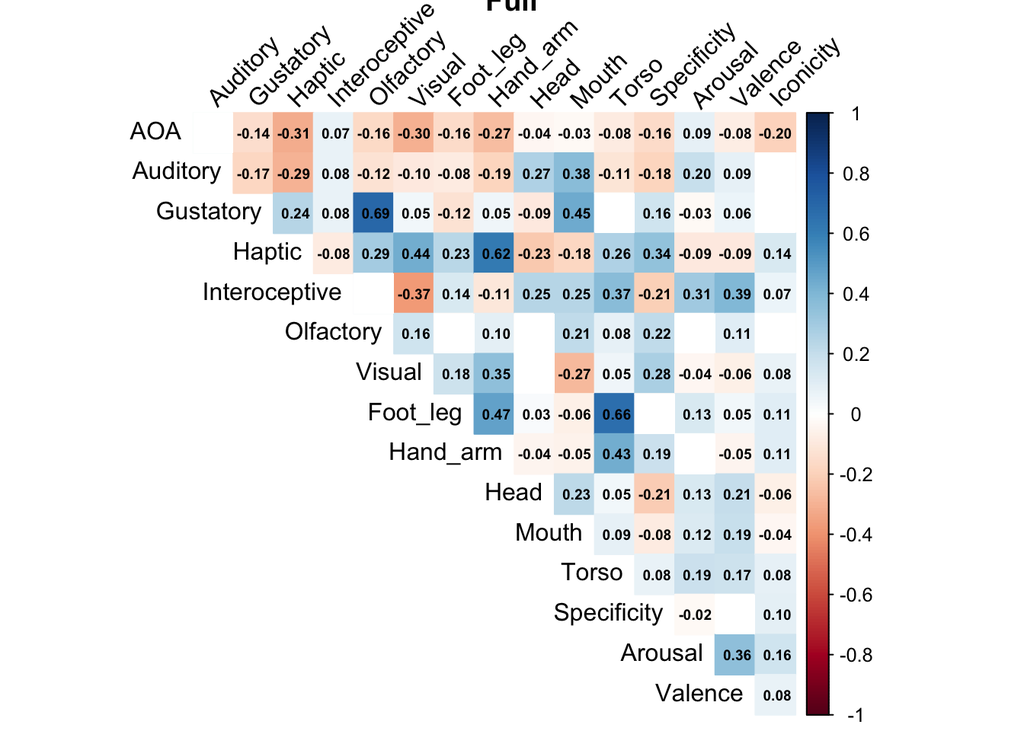

```r
# Visualize
library(corrplot)
corrplot(cor_matrix,
         method = "color",
         type = "upper",
         #order = "hclust",
         p.mat = rcorr_result$P,
         sig.level = 0.05,
         insig = "blank",       # blank out non-significant cells
         addCoef.col = "black",
         number.cex = 0.6,
         tl.col = "black",
         title = "Full",
         tl.srt = 45,
         diag = FALSE)
```

Separate correlation matrices for high vs low iconic groups

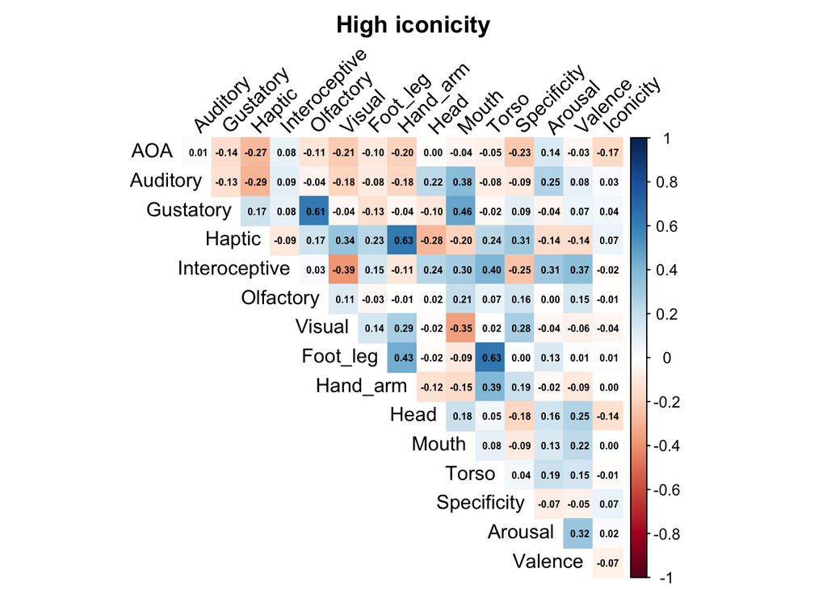

```r
cor_hi_data <- high_iconic %>%
  select(all_of(vars_test), Iconicity)
cor_low_data <- low_iconic %>%
  select(all_of(vars_test), Iconicity)

cor_high <- cor(cor_hi_data, use = "pairwise.complete.obs")
cor_low  <- cor(cor_low_data,  use = "pairwise.complete.obs")

corrplot(cor_high, method = "color", type = "upper", addCoef.col = "black",
         number.cex = 0.5, tl.col = "black", tl.srt = 45, diag = FALSE,
         title = "High iconicity", mar = c(0,0,2,0))
```

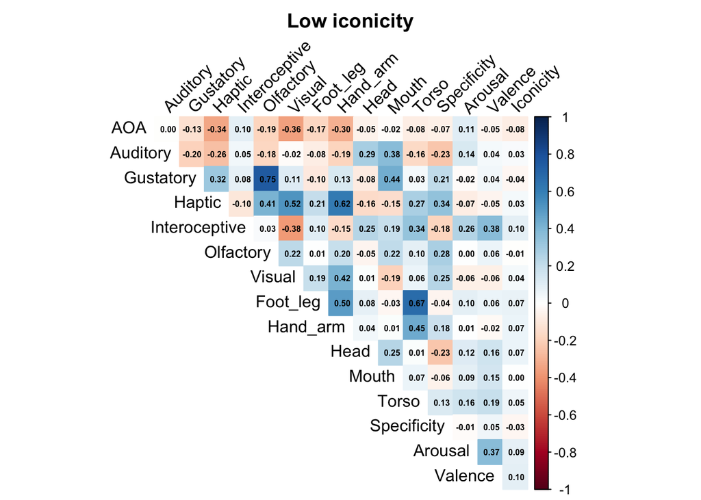

```r
corrplot(cor_low, method = "color", type = "upper", addCoef.col = "black",
         number.cex = 0.5, tl.col = "black", tl.srt = 45, diag = FALSE,
         title = "Low iconicity", mar = c(0,0,2,0))
```

# Independent Networks

## Estimate the partial correlation networks.

Select rows that will be used as nodes (remove Word, Iconic, Iconicity, Iconicity_SD, Frequency, and LogFrequency) from high_iconic and low_iconic data frames.

```r
nrow(high_iconic) == nrow(low_iconic)
```

```
## [1] TRUE
```

```r
high_iconic <- high_iconic %>%
  select(-Word, -Iconic, -Iconicity, -Iconicity_SD, -Frequency, -LogFreq)

low_iconic <- low_iconic %>%
  select(-Word, -Iconic, -Iconicity, -Iconicity_SD, -Frequency, -LogFreq)

# variable to store label names of nodes
names <- as.list(names(low_iconic))
```

Estimate network for each group, using `bootnet` package.

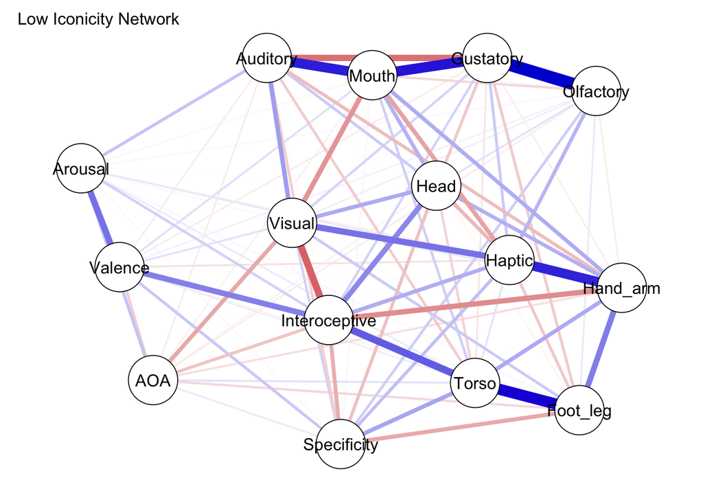

```r
net_high <- estimateNetwork(high_iconic,
  default = "EBICglasso",
  corMethod = "cor_auto",
  tuning = 0.5)

net_low <- estimateNetwork(low_iconic,
  default = "EBICglasso",
  corMethod = "cor_auto",
  tuning = 0.5)

L <- averageLayout(net_low,net_high)

plot(net_low, layout=L,label.scale = FALSE, title = "Low Iconicity Network")
```

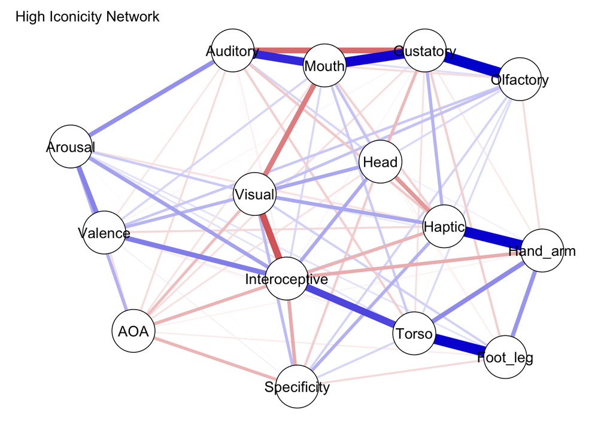

```r
plot(net_high, layout = L,label.scale = FALSE, title = "High Iconicity Network")
```

Create partial correlation plot

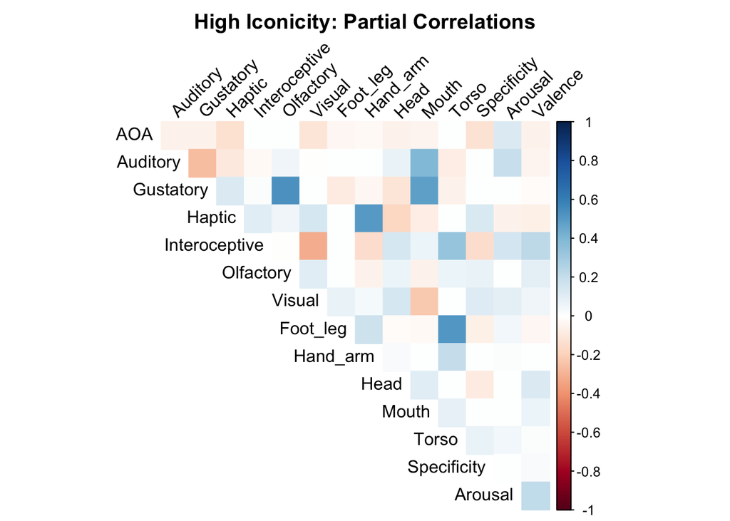

```r
pcor_high <- net_high$graph
pcor_low <- net_low$graph

# add column and row names
colnames(pcor_high) <- rownames(pcor_high) <- colnames(high_iconic)
colnames(pcor_low)  <- rownames(pcor_low)  <- colnames(low_iconic)


matrix1 <- corrplot(
  pcor_high,
  method = "color",
  type="upper",
  diag = FALSE,
  tl.srt = 45,
  tl.col = "black",
  title = "High Iconicity: Partial Correlations",
  mar = c(0,0,2,0)
)
```

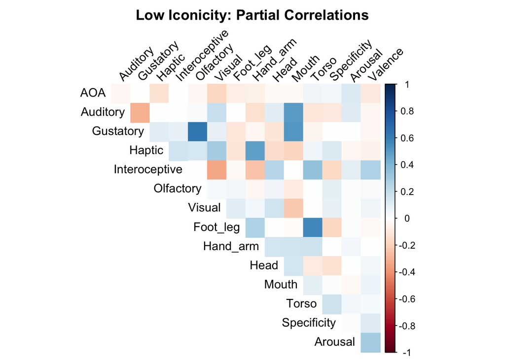

```r
matrix2 <- corrplot(
  pcor_low,
  method = "color",
  type="upper",
  diag = FALSE,
  tl.srt = 45,
  tl.col = "black",
  title = "Low Iconicity: Partial Correlations",
  mar = c(0,0,2,0)
)
```

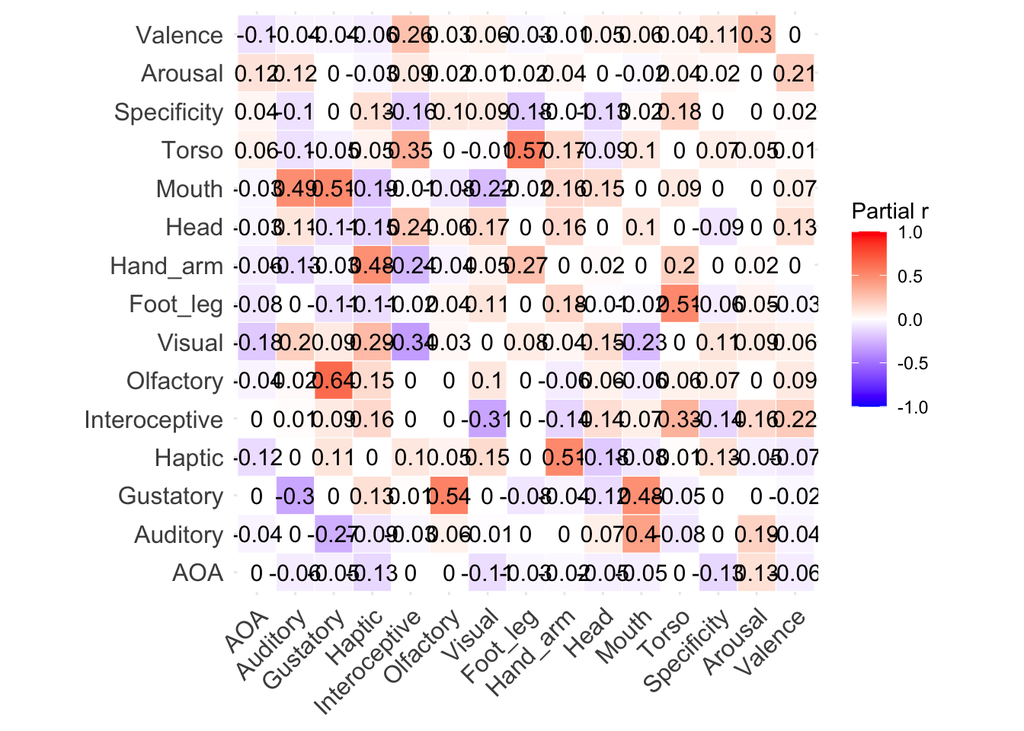

```r
# Combine the partial correlation plots into one [COME BACK LATER]
combined_matrix <- pcor_high # Use high_iconic as base
combined_matrix[upper.tri(combined_matrix)] <- pcor_low[upper.tri(pcor_low)] #fill upper with low_iconic corrplot

pc_corrplot <- ggcorrplot(
  combined_matrix, # combined partial correlation plot
  type = "full",
  legend.title = "Partial r",
  show.diag = TRUE,
  outline.col = "white",
  lab = TRUE, # display correlation coef
  hc.order = FALSE
)
pc_corrplot
```

Summary of network for high_iconic

```r
summary(pcor_high)
```

```
##       AOA              Auditory           Gustatory             Haptic
##  Min.   :-0.13059   Min.   :-0.266083   Min.   :-0.266083   Min.   :-0.17882
##  1st Qu.:-0.05793   1st Qu.:-0.049615   1st Qu.:-0.052826   1st Qu.:-0.07192
##  Median :-0.04924   Median : 0.000000   Median : 0.000000   Median : 0.00000
##  Mean   :-0.03750   Mean   : 0.009535   Mean   : 0.035720   Mean   : 0.03211
##  3rd Qu.: 0.00000   3rd Qu.: 0.029949   3rd Qu.: 0.006893   3rd Qu.: 0.11491
##  Max.   : 0.12966   Max.   : 0.395047   Max.   : 0.535513   Max.   : 0.50935
##  Interoceptive        Olfactory            Visual             Foot_leg
##  Min.   :-0.31259   Min.   :-0.05974   Min.   :-0.312586   Min.   :-0.08068
##  1st Qu.:-0.01595   1st Qu.: 0.00000   1st Qu.:-0.003612   1st Qu.:-0.02756
##  Median : 0.00000   Median : 0.05118   Median : 0.036588   Median : 0.00000
##  Mean   : 0.02748   Mean   : 0.06080   Mean   : 0.007977   Mean   : 0.03813
##  3rd Qu.: 0.12292   3rd Qu.: 0.06823   3rd Qu.: 0.097190   3rd Qu.: 0.02427
##  Max.   : 0.33453   Max.   : 0.53551   Max.   : 0.149339   Max.   : 0.51087
##     Hand_arm             Head              Mouth              Torso
##  Min.   :-0.14348   Min.   :-0.17882   Min.   :-0.22963   Min.   :-0.07984
##  1st Qu.:-0.01095   1st Qu.:-0.03222   1st Qu.:-0.03677   1st Qu.: 0.00000
##  Median : 0.00000   Median : 0.00000   Median : 0.00000   Median : 0.01296
##  Mean   : 0.04722   Mean   : 0.01549   Mean   : 0.05067   Mean   : 0.08016
##  3rd Qu.: 0.03070   3rd Qu.: 0.08604   3rd Qu.: 0.07895   3rd Qu.: 0.07908
##  Max.   : 0.50935   Max.   : 0.14865   Max.   : 0.48056   Max.   : 0.51087
##   Specificity            Arousal            Valence
##  Min.   :-1.443e-01   Min.   :-0.05039   Min.   :-0.06549
##  1st Qu.:-3.181e-02   1st Qu.: 0.00000   1st Qu.:-0.02296
##  Median : 0.000e+00   Median : 0.01700   Median : 0.01296
##  Mean   : 2.895e-05   Mean   : 0.05677   Mean   : 0.04065
##  3rd Qu.: 4.601e-02   3rd Qu.: 0.11019   3rd Qu.: 0.08090
##  Max.   : 1.314e-01   Max.   : 0.21338   Max.   : 0.22476
```

Summary of network for low_iconic

```r
summary(pcor_low)
```

```
##       AOA              Auditory          Gustatory            Haptic
##  Min.   :-0.17648   Min.   :-0.30098   Min.   :-0.30098   Min.   :-0.18745
##  1st Qu.:-0.07106   1st Qu.:-0.06855   1st Qu.:-0.04392   1st Qu.:-0.08418
##  Median :-0.02988   Median : 0.00000   Median : 0.00000   Median : 0.00000
##  Mean   :-0.03053   Mean   : 0.01564   Mean   : 0.05241   Mean   : 0.04758
##  3rd Qu.: 0.00000   3rd Qu.: 0.06329   3rd Qu.: 0.08658   3rd Qu.: 0.13776
##  Max.   : 0.12085   Max.   : 0.49270   Max.   : 0.63794   Max.   : 0.48028
##  Interoceptive        Olfactory            Visual             Foot_leg
##  Min.   :-0.33679   Min.   :-0.08117   Min.   :-0.336792   Min.   :-0.17629
##  1st Qu.:-0.01611   1st Qu.: 0.00000   1st Qu.:-0.004603   1st Qu.:-0.05168
##  Median : 0.00000   Median : 0.02059   Median : 0.047217   Median : 0.00000
##  Mean   : 0.02854   Mean   : 0.06164   Mean   : 0.023257   Mean   : 0.03087
##  3rd Qu.: 0.12763   3rd Qu.: 0.04982   3rd Qu.: 0.097618   3rd Qu.: 0.02915
##  Max.   : 0.34559   Max.   : 0.63794   Max.   : 0.294775   Max.   : 0.56608
##     Hand_arm             Head               Mouth              Torso
##  Min.   :-0.24119   Min.   :-0.148527   Min.   :-0.22117   Min.   :-0.101375
##  1st Qu.:-0.03555   1st Qu.:-0.058109   1st Qu.:-0.02501   1st Qu.:-0.004603
##  Median : 0.00000   Median : 0.004916   Median : 0.00000   Median : 0.041488
##  Mean   : 0.05354   Mean   : 0.029387   Mean   : 0.06221   Mean   : 0.086437
##  3rd Qu.: 0.16085   3rd Qu.: 0.130117   3rd Qu.: 0.12503   3rd Qu.: 0.133032
##  Max.   : 0.48028   Max.   : 0.243407   Max.   : 0.51371   Max.   : 0.566075
##   Specificity           Arousal             Valence
##  Min.   :-0.176286   Min.   :-0.034094   Min.   :-0.09761
##  1st Qu.:-0.053466   1st Qu.: 0.001133   1st Qu.:-0.03221
##  Median : 0.015045   Median : 0.015947   Median : 0.02789
##  Mean   : 0.006855   Mean   : 0.048345   Mean   : 0.04230
##  3rd Qu.: 0.093457   3rd Qu.: 0.068524   3rd Qu.: 0.05854
##  Max.   : 0.179088   Max.   : 0.298182   Max.   : 0.29818
```

Create centrality figure

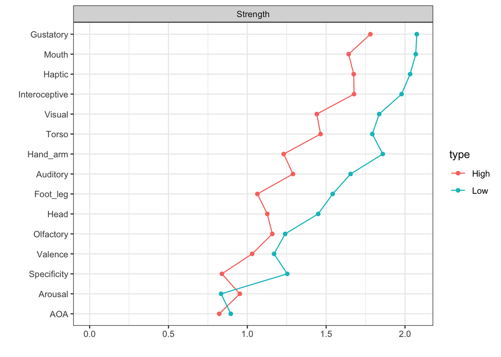

```r
centralityPlot(list(High = net_high, Low = net_low), include = c("Strength"), decreasing = FALSE, orderBy = "Strength")
```

```r
centrality_table <- centralityTable(net_high, net_low, standardized = TRUE)
centrality_table %>%
  filter(measure == "Strength") %>%
  arrange(desc(value))
```

```
##      graph type          node  measure       value
## 1  graph 1   NA     Gustatory Strength  1.57475402
## 2  graph 1   NA Interoceptive Strength  1.24907328
## 3  graph 1   NA        Haptic Strength  1.24239723
## 4  graph 2   NA     Gustatory Strength  1.17985883
## 5  graph 2   NA         Mouth Strength  1.16410913
## 6  graph 1   NA         Mouth Strength  1.14144840
## 7  graph 2   NA        Haptic Strength  1.07900821
## 8  graph 2   NA Interoceptive Strength  0.95048995
## 9  graph 2   NA      Hand_arm Strength  0.66670783
## 10 graph 2   NA        Visual Strength  0.61262710
## 11 graph 1   NA         Torso Strength  0.58168312
## 12 graph 2   NA         Torso Strength  0.50914527
## 13 graph 1   NA        Visual Strength  0.50599665
## 14 graph 2   NA      Auditory Strength  0.18135662
```

[output cut: 16 more lines]

Bootstrap Stability

```r
boot_high <- bootnet(net_high, nBoots = 1000, type = "nonparametric")
```

[output not shown]

[output not shown]

[output not shown]

[output not shown]

[output not shown]

[output not shown]

[output not shown]

[output not shown]

[output not shown]

[output not shown]

[output not shown]

[output not shown]

[output not shown]

[output not shown]

[output not shown]

[output not shown]

[output not shown]

[output not shown]

[output not shown]

[output not shown]

[output not shown]

[output not shown]

[output not shown]

[output not shown]

[output not shown]

[output not shown]

[output not shown]

[output not shown]

[output not shown]

[output not shown]

[output not shown]

[output not shown]

[output not shown]

[output not shown]

[output not shown]

[output not shown]

[output not shown]

[output not shown]

[output not shown]

[output not shown]

[output not shown]

[output not shown]

[output not shown]

[output not shown]

[output not shown]

[output not shown]

[output not shown]

[output not shown]

[output not shown]

[output not shown]

[output not shown]

[output not shown]

[output not shown]

[output not shown]

[output not shown]

[output not shown]

[output not shown]

[output not shown]

[output not shown]

[output not shown]

[output not shown]

[output not shown]

[output not shown]

[output not shown]

[output not shown]

[output not shown]

[output not shown]

[output not shown]

[output not shown]

[output not shown]

[output not shown]

[output not shown]

[output not shown]

[output not shown]

[output not shown]

[output not shown]

[output not shown]

[output not shown]

[output not shown]

[output not shown]

[output not shown]

[output not shown]

[output not shown]

[output not shown]

[output not shown]

[output not shown]

[output not shown]

[output not shown]

[output not shown]

[output not shown]

[output not shown]

[output not shown]

[output not shown]

[output not shown]

[output not shown]

[output not shown]

[output not shown]

[output not shown]

[output not shown]

[output not shown]

[output not shown]

[output not shown]

[output not shown]

[output not shown]

[output not shown]

[output not shown]

[output not shown]

[output not shown]

[output not shown]

[output not shown]

[output not shown]

```r
boot_low  <- bootnet(net_low,  nBoots = 1000, type = "nonparametric")
```

[output not shown]

[output not shown]

[output not shown]

[output not shown]

[output not shown]

[output not shown]

[output not shown]

[output not shown]

[output not shown]

[output not shown]

[output not shown]

[output not shown]

[output not shown]

[output not shown]

[output not shown]

[output not shown]

[output not shown]

[output not shown]

[output not shown]

[output not shown]

[output not shown]

[output not shown]

[output not shown]

[output not shown]

[output not shown]

[output not shown]

[output not shown]

[output not shown]

[output not shown]

[output not shown]

[output not shown]

[output not shown]

[output not shown]

[output not shown]

[output not shown]

[output not shown]

[output not shown]

[output not shown]

[output not shown]

[output not shown]

[output not shown]

[output not shown]

[output not shown]

[output not shown]

[output not shown]

[output not shown]

[output not shown]

[output not shown]

[output not shown]

[output not shown]

[output not shown]

[output not shown]

[output not shown]

[output not shown]

[output not shown]

[output not shown]

[output not shown]

[output not shown]

[output not shown]

[output not shown]

[output not shown]

[output not shown]

[output not shown]

[output not shown]

[output not shown]

[output not shown]

[output not shown]

[output not shown]

[output not shown]

[output not shown]

[output not shown]

[output not shown]

[output not shown]

[output not shown]

[output not shown]

[output not shown]

[output not shown]

[output not shown]

[output not shown]

[output not shown]

[output not shown]

[output not shown]

[output not shown]

[output not shown]

[output not shown]

[output not shown]

[output not shown]

[output not shown]

[output not shown]

[output not shown]

[output not shown]

[output not shown]

[output not shown]

[output not shown]

[output not shown]

[output not shown]

[output not shown]

[output not shown]

[output not shown]

[output not shown]

[output not shown]

[output not shown]

[output not shown]

[output not shown]

[output not shown]

[output not shown]

[output not shown]

[output not shown]

[output not shown]

[output not shown]

[output not shown]

[output not shown]

[output not shown]

[output not shown]

[output not shown]

[output not shown]

[output not shown]

[output not shown]

[output not shown]

[output not shown]

[output not shown]

[output not shown]

[output not shown]

[output not shown]

[output not shown]

[output not shown]

[output not shown]

[output not shown]

[output not shown]

[output not shown]

[output not shown]

[output not shown]

[output not shown]

[output not shown]

[output not shown]

[output not shown]

[output not shown]

[output not shown]

[output not shown]

[output not shown]

[output not shown]

[output not shown]

[output not shown]

[output not shown]

[output not shown]

[output not shown]

[output not shown]

[output not shown]

[output not shown]

[output not shown]

[output not shown]

[output not shown]

[output not shown]

[output not shown]

[output not shown]

[output not shown]

[output not shown]

```r
# node strength stability
case_high <- bootnet(net_high, nBoots = 1000, type = "case", statistics = "strength")
```

[output not shown]

[output not shown]

[output not shown]

[output not shown]

[output not shown]

[output not shown]

[output not shown]

[output not shown]

[output not shown]

[output not shown]

[output not shown]

[output not shown]

[output not shown]

[output not shown]

[output not shown]

[output not shown]

[output not shown]

[output not shown]

[output not shown]

[output not shown]

[output not shown]

```r
case_low  <- bootnet(net_low,  nBoots = 1000, type = "case", statistics = "strength")
```

[output not shown]

[output not shown]

[output not shown]

[output not shown]

[output not shown]

[output not shown]

[output not shown]

[output not shown]

[output not shown]

[output not shown]

[output not shown]

[output not shown]

[output not shown]

[output not shown]

[output not shown]

[output not shown]

[output not shown]

[output not shown]

[output not shown]

[output not shown]

[output not shown]

[output not shown]

[output not shown]

[output not shown]

[output not shown]

[output not shown]

[output not shown]

[output not shown]

[output not shown]

[output not shown]

[output not shown]

[output not shown]

[output not shown]

[output not shown]

[output not shown]

[output not shown]

[output not shown]

[output not shown]

[output not shown]

[output not shown]

[output not shown]

[output not shown]

[output not shown]

[output not shown]

[output not shown]

[output not shown]

[output not shown]

[output not shown]

[output not shown]

[output not shown]

[output not shown]

[output not shown]

[output not shown]

[output not shown]

[output not shown]

[output not shown]

[output not shown]

[output not shown]

[output not shown]

[output not shown]

[output not shown]

[output not shown]

[output not shown]

[output not shown]

[output not shown]

[output not shown]

[output not shown]

[output not shown]

[output not shown]

[output not shown]

[output not shown]

[output not shown]

[output not shown]

[output not shown]

[output not shown]

[output not shown]

[output not shown]

[output not shown]

[output not shown]

[output not shown]

[output not shown]

[output not shown]

[output not shown]

[output not shown]

[output not shown]

[output not shown]

[output not shown]

[output not shown]

[output not shown]

[output not shown]

[output not shown]

[output not shown]

[output not shown]

[output not shown]

[output not shown]

[output not shown]

[output not shown]

[output not shown]

[output not shown]

[output not shown]

[output not shown]

[output not shown]

[output not shown]

[output not shown]

[output not shown]

[output not shown]

[output not shown]

[output not shown]

```r
# compare networks directly
nct_result <- NCT(high_iconic, low_iconic, it = 10000,
                   test.edges = TRUE, edges = "all",
                   test.centrality = TRUE, centrality = "strength",
                   p.adjust.methods = "BH")
```

[output not shown]